# Bike Vendors Final Report

Michelle Howe

April 27, 2019

# Exploratory Analysis of Bike Vendors Dataset

## Questions to Answer

1. What types of bikes are purchased most frequently?
2. What types of bikes are purchased least frequently?
3. Can vendors be separated into smaller groups to provide more targeted advertising?
4. Are there any bikes that do not follow anticipated sales based on others in their category (e.g. any outliers)?

## Data Exploration

### Exploratory Plots

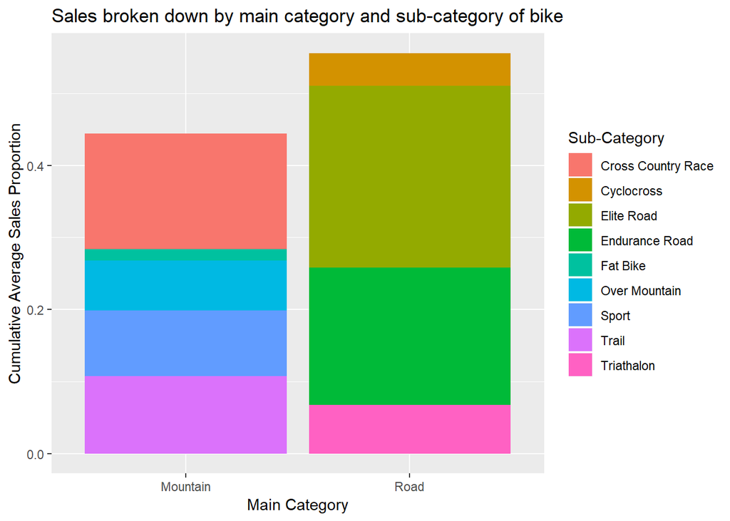

**Analysis:** Road bikes make up the highest cumulative average sales proportion of all bikes. Of those, Elite Road makes up the largest cumulative portion.  
The smallest cumulative portion is the Fat Bike (a Mountain Bike).

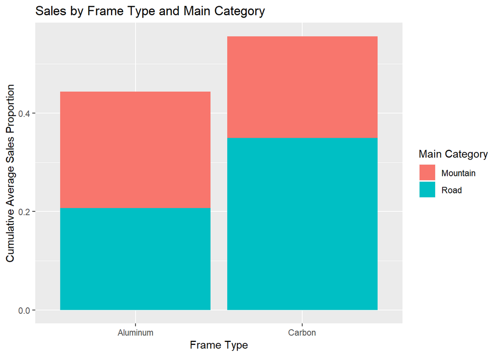

**Analysis:** Carbon bikes make up a larger cumulative average sales proportion.  
Of those, Road Carbon frame bikes make up the largest cumulative average sales proportion.

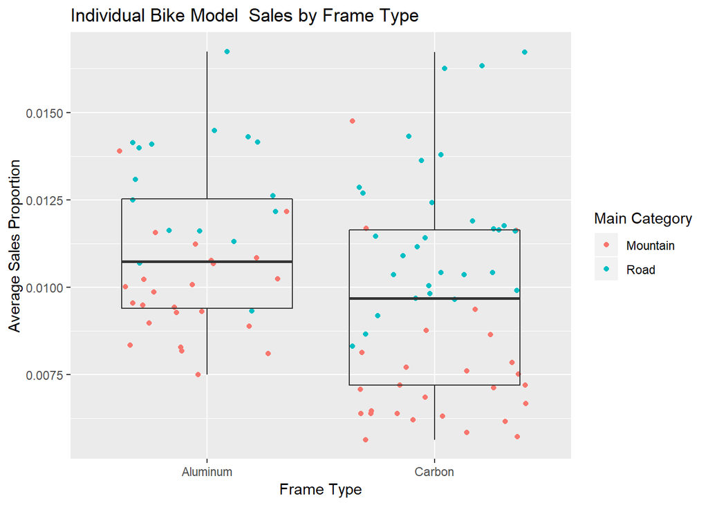

**Analysis:** Looking at this boxplot, we can see that the carbon-frame bicycles actually individually have a lower average sales proportion per bicycle model. It is clear though, that Road models in general have higher average sales.

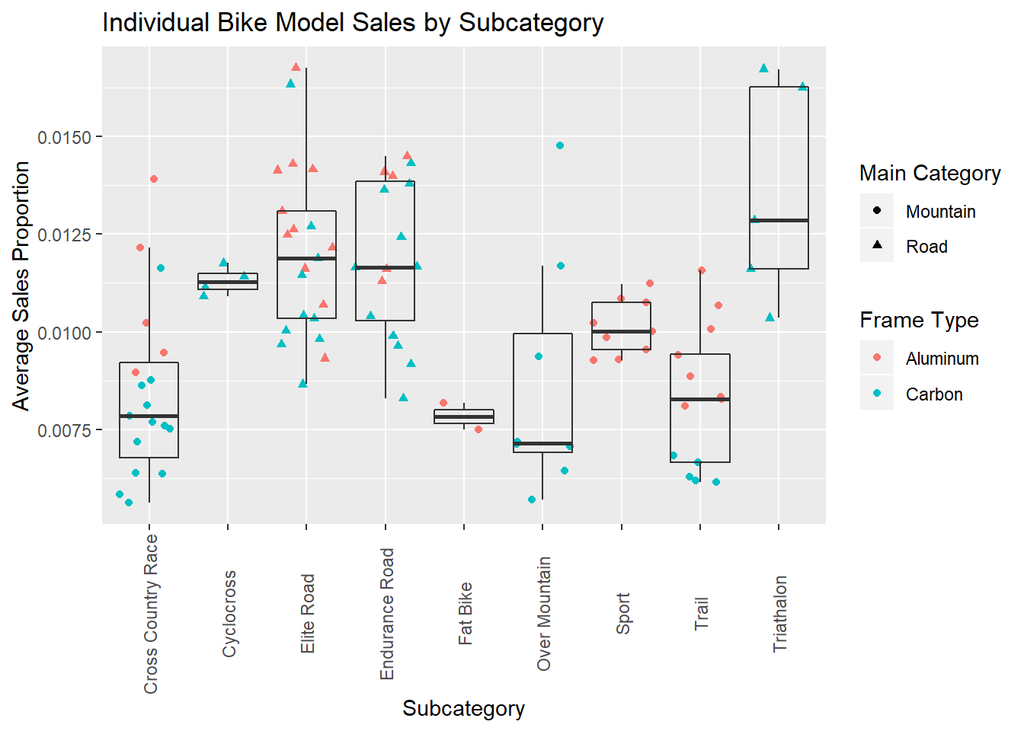

**Analysis:** The highest average sales proportion comes from the Triathalon bikes (Carbon frame Road models). Road models constitute the highest average individual bike model sales. The lowest average sales proportion comes from the Over Mountain bikes (Carbon frame Mountain Models).  
Looking at individual data points, there are bikes from the Elite Road line (Road Models) and bikes from the Triathalon line that are the leading sellers. The closest Mountain Model to them is one from the Over Mountain line interestingly enough. Clearly, here, the road models generally are higher sellers than the Mountain.

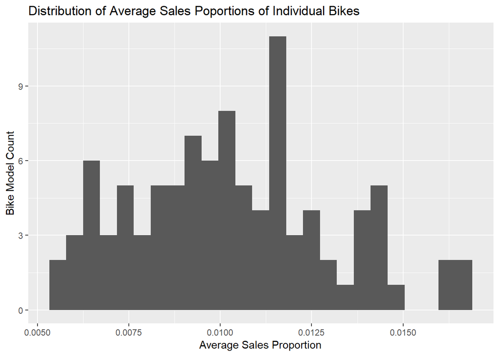

**Analysis:** We can see here that distribution is not completely normal, but fairly close.  
There are some outliers on the higher end of the x-axis.

### Regression Analysis

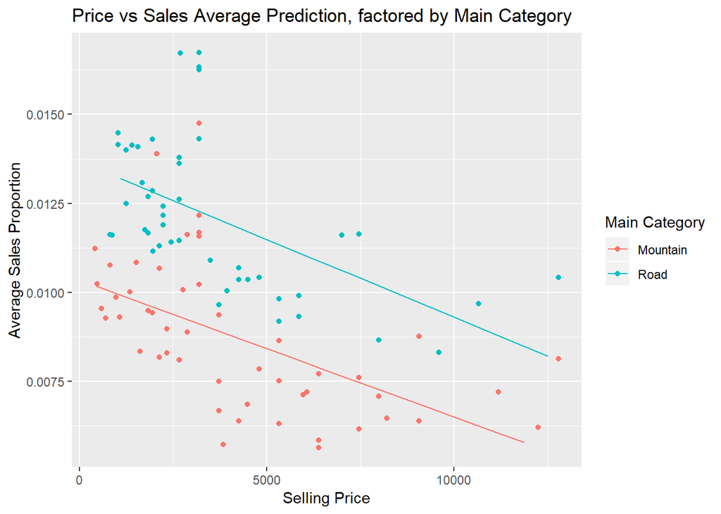

**Analysis:** Regression analysis was completed with average sales proportion as the dependent variable and price as the independed variable. “Main Category” was added in as a factor. Looking at the plotted data, it does not appear completely linear.  
However a linear model was attempted. Using a Gaussian GLM and adding in a “Main Category” factor produced this regression. In general from this model visualization, we clearly see that bikes with lower selling prices generally have a higher sales proportion, and that generally the the Mountain bikes have a lower sale proportion than the Road bikes.

```
##
## Call:
## glm(formula = avgsales ~ price * category1, family = "gaussian",
##     data = bike_averages)
##
## Deviance Residuals:
##        Min          1Q      Median          3Q         Max
## -0.0031482  -0.0012345  -0.0003614   0.0010776   0.0056430
##
## Coefficients:
##                       Estimate Std. Error t value Pr(>|t|)
## (Intercept)          1.034e-02  4.342e-04  23.823  < 2e-16 ***
## price               -3.849e-07  8.328e-08  -4.622 1.22e-05 ***
## category1Road        3.326e-03  6.245e-04   5.325 6.98e-07 ***
## price:category1Road -5.211e-08  1.303e-07  -0.400     0.69
## ---
## Signif. codes:  0 '***' 0.001 '**' 0.01 '*' 0.05 '.' 0.1 ' ' 1
##
## (Dispersion parameter for gaussian family taken to be 3.209761e-06)
##
##     Null deviance: 0.00070463  on 96  degrees of freedom
## Residual deviance: 0.00029851  on 93  degrees of freedom
## AIC: -945.79
##
## Number of Fisher Scoring iterations: 2
```

**Analysis of Regression Summary Table:** The median deviance residual is very close to zero, so the model is not biased (does not over or underestimate). We see that the intercept, price and category1Road (Main Category) coefficients are significant. There does not appear to be a statistically significant interaction effect between price and Main Category.

#### Model Diagnostics

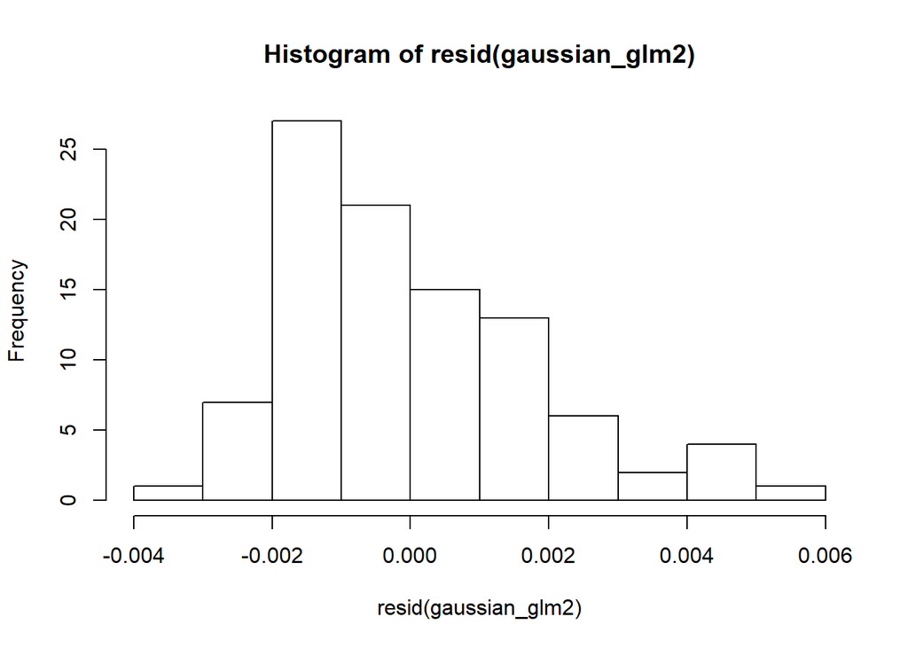

The histogram of residuals looks skewed.

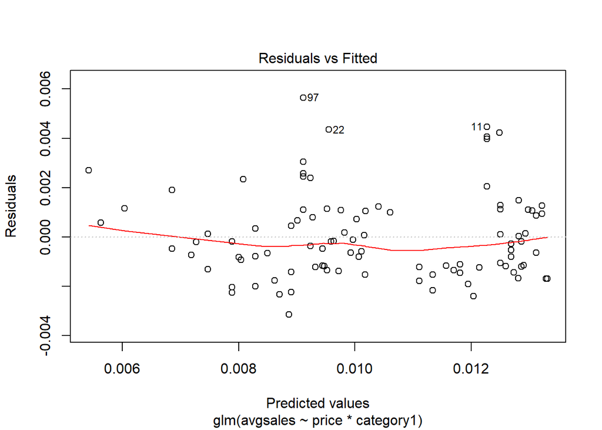

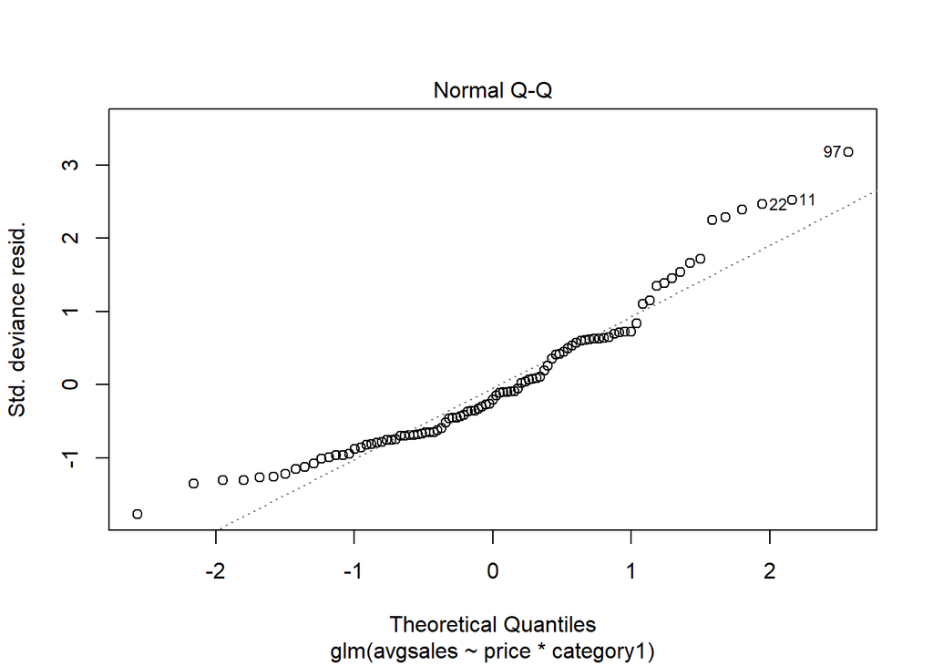

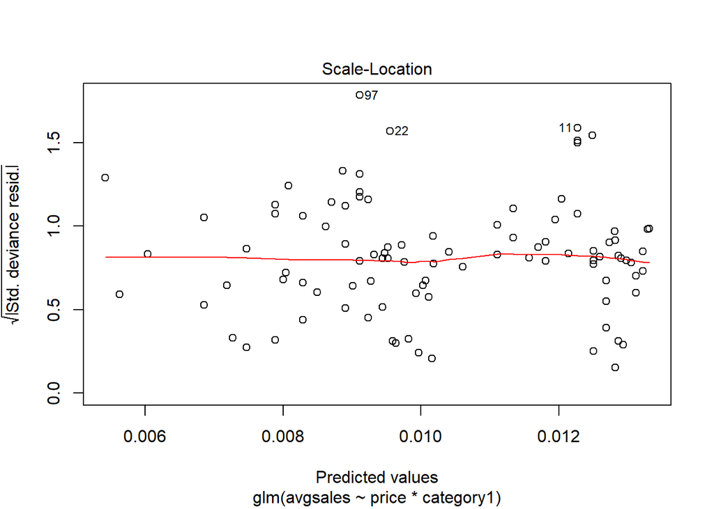

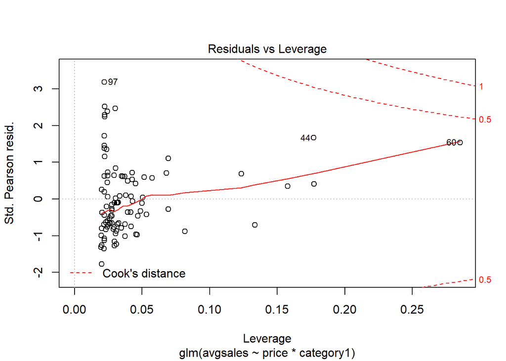

### Cluster Analysis of Vendors Using K Means Clustering

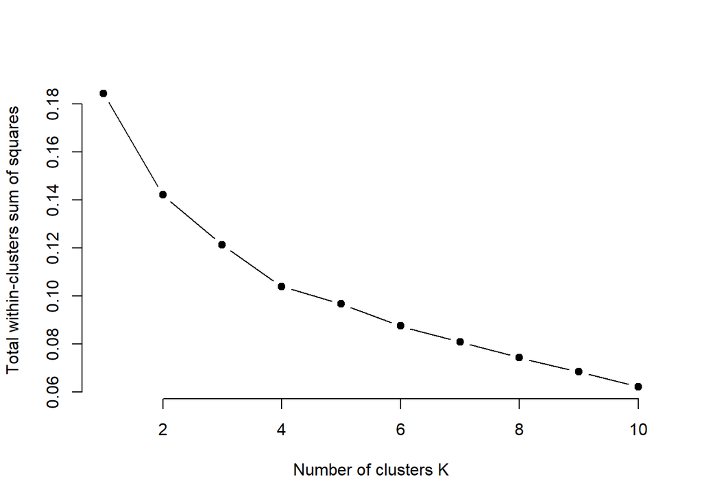

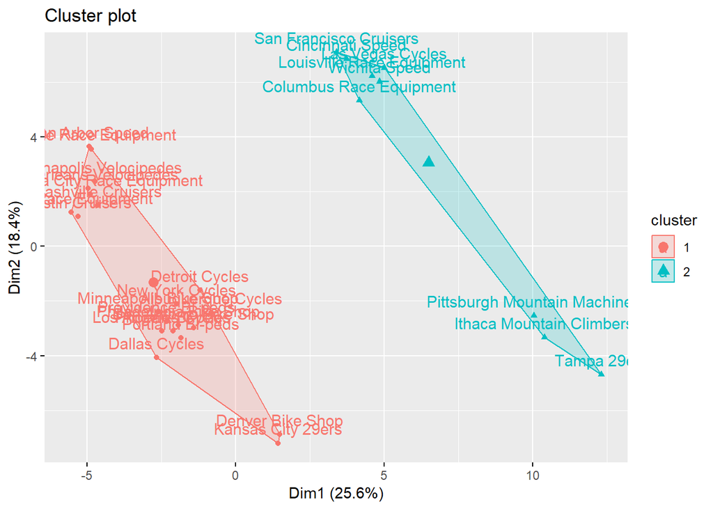

## Answers for Initial Questions

1. What types of bikes are purchased most frequently?
- Road bikes cumulatively constitute the largest proportion of average sales, with Elite Road and Endurance Road sub-categories as the leaders. Of the Mountain bikes, Cross Country Race constitute the largest proportion. Cumulatively, carbon frame bikes constitute the largest proportion of sales.
- On an individual model basis, aluminum frame bikes tended to have higher average sales proportions. Category-wise, Road bikes tended to perform better. Almost all of the models with the highest averages were Road bikes.
2. What types of bikes are purchased least frequently?
- On an individual model basis, the lowest performers were carbon frame Mountain bikes. All of the carbon frame Trail bikes had low averages, and the models with the lowest averages were carbon frames from the Cross Country Race and Over Mountain sub-categories of Mountain bikes.
3. Can vendors be separated into smaller groups to provide more targeted advertising?
- Cluster analysis does filter the vendors in to 2 subgroups:
  - Cluster 1: Albuquerque Cycles, Ann Arbor Speed, Austin Cruisers, Dallas Cycles, Denver Bike Shop, Detroit Cycles, Indianapolis Velocipedes, Kansas City 29ers, Los Angeles Cycles, Miami Race Equipment, Minneapolis Bike Shop, Nashville Cruisers, New Orleans Velocipedes, New York Cycles, Oklahoma City Race Equipment, Philadelphia Bike Shop, Phoenix Bi-peds, Portland Bi-peds, Providence Bi-peds, San Antonio Bike Shop, Seattle Race Equipment
  - Cluster 2: Cincinnati Speed, Columbus Race Equipment, Ithaca Mountain Climbers, Las Vegas Cycles, Louisville Race Equipment, Pittsburgh Mountain Machines, San Francisco Cruisers, Tampa 29ers, Wichita Speed
- Further analysis can be performed to better characterize how buying habits differ between these two clusters. This will allow for more personalized/targeted advertising in the future.
4. Are there any bikes that do not follow anticipated sales based on others in their category (e.g. any outliers)?
- The model created found six outliers: CADD12 Red (aluminum road), F-Si 2 (aluminum mountain), Slice Ultegra (carbon road), Slice Ultegra D12 (carbon road), Supersix Evo Ultegra 3 (carbon road), and Trigger Carbon 4 (carbon mountain).
- It is important to note, though, that the model created here was not ideal as it had assumption violations. A different model may provide a more accurate identification of outliers.